# Project 1 - Understanding Happiness Levels in The Americas

## Introduction

It is important for the leaders of the world to understand the happiness levels of the people they represent. Thus, I consider that analyzing the factors that are involved to people's happiness is an interesting subject. Also, it is interesting to learn what countries are considered the happiest and what other factors they have that can add to those happiness levels. Thus, compared to other countries with lower happiness ranking.

The main goal of this project is to understand the happiness levels in North, Central, and South America over the years (2016, 2017, 2018, 2019). This is with the intention of understanding the importance that each category imply to the happiness of each country. They are a couple of fields that are taken into consideration when it comes to determining the happiness levels of a country such as Economy, Family, Health, Freedom, Trust Government Corruption, Generosity, and Dystopia (which will not be taken into consideration). Those fields contribute to the final rank of happiness in these datasets.

What this project will try to solve is how happiness in countries can vary, what are the main attributes that contribute to these changes, check if there are countries that have changed their rank and what was the main factor, and compare the conditions of different countries to understand if there is a same factor.

It is important to highlight that the data is limited.

This Dataset is found on this following link: https://www.kaggle.com/datasets/unsdsn/world-happiness/data

## Pre-processing Data

I would consider these datasets to be clean datasets. However, the datasets are world-wide. Thus, I will be only modifying the set to make sure I only get values in the Americas, and I will go from there to check that all the other cleaning steps are done.

I first start with importing the libraries we will be using for this project and loading everything.

```python
import pandas as pd
import numpy as np
import matplotlib.pyplot as plt
import seaborn as sns
```

```python
data_2016 = pd.read_csv("dataset/2016.csv")
data_2017 = pd.read_csv("dataset/2017.csv")
data_2018 = pd.read_csv("dataset/2018.csv")
data_2019 = pd.read_csv("dataset/2019.csv")
```

```python
df_2016 = pd.DataFrame(data_2016)
df_2017 = pd.DataFrame(data_2017)
df_2018 = pd.DataFrame(data_2018)
df_2019 = pd.DataFrame(data_2019)

df_2016['Year'] = '2016'
df_2017['Year'] = '2017'
df_2018['Year'] = '2018'
df_2019['Year'] = '2019'
```

I check for null values and noticed that only the dataset for 2018 have a null value. Thus, I will just fix that by adding the mean in that place.

```python
df_2018.isnull().sum()
```

```
Overall rank       0
Country            0
Happiness Score    0
Economy            0
Social support     0
Health             0
Freedom            0
Generosity         0
Trust              1
Year               0
dtype: int64
```

```python
df_2018['Trust'] = df_2018['Trust'].fillna(df_2018['Trust'].mean())
```

```python
df_2016.columns
```

```
Index(['Country', 'Region', 'Happiness Rank', 'Happiness Score',
       'Lower Confidence Interval', 'Upper Confidence Interval', 'Economy',
       'Social support', 'Health', 'Freedom', 'Trust', 'Generosity',
       'Dystopia', 'Year'],
      dtype='object')
```

### Fixing Datasets

I noticed that the column names were long for me to be able to work with them easily. Thus, I decided to trim the name of the columns and adapt the naming to the dataset from 2016. Here is relevant information that was cut off the naming of the fields:

- Economy - GDP per Capita
- Health - Life Expectancy
- Trust - Government Corruptions

Also, although the Low Confidence and High Confidence intervals are good to have, they are not relevant to the type of solution this project is aiming for so I will be dropping them. I also dropped the Dystopia field because the dataset says it is supposed to be an imaginary country with the least economy, health, trust, etc. However, they added this imaginary value to the score of each country as a type to showcase that each country has some magic field for happiness (unexplained happiness). For the purpose of this project, I will be not considering that imaginary value.

```python
df_2016.columns
```

```
Index(['Country', 'Region', 'Happiness Rank', 'Happiness Score',
       'Lower Confidence Interval', 'Upper Confidence Interval', 'Economy',
       'Social support', 'Health', 'Freedom', 'Trust', 'Generosity',
       'Dystopia', 'Year'],
      dtype='object')
```

```python
df_2016 = df_2016.drop(['Lower Confidence Interval', 'Happiness Rank', 'Dystopia', 'Upper Confidence Interval'], axis=1)
```

```python
df_2017.columns
```

```
Index(['Country', 'Happiness Rank', 'Happiness Score', 'Whisker.high',
       'Whisker.low', 'Economy', 'Social support', 'Health', 'Freedom',
       'Generosity', 'Trust', 'Dystopia', 'Year'],
      dtype='object')
```

```python
df_2017 = df_2017.drop(['Happiness Rank','Whisker.high', 'Whisker.low','Dystopia'], axis=1)
```

```python
df_2018.columns
```

```
Index(['Overall rank', 'Country', 'Happiness Score', 'Economy',
       'Social support', 'Health', 'Freedom', 'Generosity', 'Trust', 'Year'],
      dtype='object')
```

```python
df_2018 = df_2018.drop(['Overall rank'], axis=1)
```

```python
df_2019.columns
```

```
Index(['Overall rank', 'Country', 'Happiness Score', 'Economy',
       'Social support', 'Health', 'Freedom', 'Generosity', 'Trust', 'Year'],
      dtype='object')
```

```python
df_2019 = df_2019.drop(['Overall rank'], axis=1)
```

### Data Cleaning and Data Frames

In this process, I used the dataframe 2016 to make these changes since it contains the region of each country which makes the selection of countries in the American continents easier to select (which the next block explains how I did it). Then, I decided to grab this data frame as the identifier for the other data frames to grab the countries in the Americas. I, then, made sure to verify that other irrelevant columns were dropped.

```python
df_2016 = df_2016[df_2016['Region'].str.contains('America')]
df_2016.head()
```

|  | Country | Region | Happiness Score | Economy | Social support | Health | Freedom | Trust | Generosity | Year |
| --- | --- | --- | --- | --- | --- | --- | --- | --- | --- | --- |
| 5 | Canada | North America | 7.404 | 1.44015 | 1.09610 | 0.82760 | 0.57370 | 0.31329 | 0.44834 | 2016 |
| 12 | United States | North America | 7.104 | 1.50796 | 1.04782 | 0.77900 | 0.48163 | 0.14868 | 0.41077 | 2016 |
| 13 | Costa Rica | Latin America and Caribbean | 7.087 | 1.06879 | 1.02152 | 0.76146 | 0.55225 | 0.10547 | 0.22553 | 2016 |
| 14 | Puerto Rico | Latin America and Caribbean | 7.039 | 1.35943 | 1.08113 | 0.77758 | 0.46823 | 0.12275 | 0.22202 | 2016 |
| 16 | Brazil | Latin America and Caribbean | 6.952 | 1.08754 | 1.03938 | 0.61415 | 0.40425 | 0.14166 | 0.15776 | 2016 |

```python
df_2016 = df_2016.drop(['Region'], axis=1)
```

```python
for index, row in df_2017.iterrows():
    if row['Country'] not in df_2016['Country'].values:
        df_2017.drop(index, inplace=True)
df_2017.head()
```

|  | Country | Happiness Score | Economy | Social support | Health | Freedom | Generosity | Trust | Year |
| --- | --- | --- | --- | --- | --- | --- | --- | --- | --- |
| 6 | Canada | 7.316 | 1.479204 | 1.481349 | 0.834558 | 0.611101 | 0.435540 | 0.287372 | 2017 |
| 11 | Costa Rica | 7.079 | 1.109706 | 1.416404 | 0.759509 | 0.580132 | 0.214613 | 0.100107 | 2017 |
| 13 | United States | 6.993 | 1.546259 | 1.419921 | 0.774287 | 0.505741 | 0.392579 | 0.135639 | 2017 |
| 19 | Chile | 6.652 | 1.252785 | 1.284025 | 0.819480 | 0.376895 | 0.326662 | 0.082288 | 2017 |
| 21 | Brazil | 6.635 | 1.107353 | 1.431306 | 0.616552 | 0.437454 | 0.162350 | 0.111093 | 2017 |

```python
for index, row in df_2018.iterrows():
    if row['Country'] not in df_2016['Country'].values:
        df_2018.drop(index, inplace=True)

df_2018.head()
```

|  | Country | Happiness Score | Economy | Social support | Health | Freedom | Generosity | Trust | Year |
| --- | --- | --- | --- | --- | --- | --- | --- | --- | --- |
| 6 | Canada | 7.328 | 1.330 | 1.532 | 0.896 | 0.653 | 0.321 | 0.291 | 2018 |
| 12 | Costa Rica | 7.072 | 1.010 | 1.459 | 0.817 | 0.632 | 0.143 | 0.101 | 2018 |
| 17 | United States | 6.886 | 1.398 | 1.471 | 0.819 | 0.547 | 0.291 | 0.133 | 2018 |
| 23 | Mexico | 6.488 | 1.038 | 1.252 | 0.761 | 0.479 | 0.069 | 0.095 | 2018 |
| 24 | Chile | 6.476 | 1.131 | 1.331 | 0.808 | 0.431 | 0.197 | 0.061 | 2018 |

```python
for index, row in df_2019.iterrows():
    if row['Country'] not in df_2016['Country'].values:
        df_2019.drop(index, inplace=True)

df_2019.head()
```

|  | Country | Happiness Score | Economy | Social support | Health | Freedom | Generosity | Trust | Year |
| --- | --- | --- | --- | --- | --- | --- | --- | --- | --- |
| 8 | Canada | 7.278 | 1.365 | 1.505 | 1.039 | 0.584 | 0.285 | 0.308 | 2019 |
| 11 | Costa Rica | 7.167 | 1.034 | 1.441 | 0.963 | 0.558 | 0.144 | 0.093 | 2019 |
| 18 | United States | 6.892 | 1.433 | 1.457 | 0.874 | 0.454 | 0.280 | 0.128 | 2019 |
| 22 | Mexico | 6.595 | 1.070 | 1.323 | 0.861 | 0.433 | 0.074 | 0.073 | 2019 |
| 25 | Chile | 6.444 | 1.159 | 1.369 | 0.920 | 0.357 | 0.187 | 0.056 | 2019 |

### Adding All The Data Frames Together

Here, I added all the data frames of the different years together into a bigger dataset for easier manipulation when it comes to data visualizations compared to the years

```python
df = pd.concat([df_2016, df_2017, df_2018, df_2019], ignore_index=True)
```

```python
df.isna().sum()
```

```
Country            0
Happiness Score    0
Economy            0
Social support     0
Health             0
Freedom            0
Trust              0
Generosity         0
Year               0
dtype: int64
```

```python
df.dtypes
```

```
Country             object
Happiness Score    float64
Economy            float64
Social support     float64
Health             float64
Freedom            float64
Trust              float64
Generosity         float64
Year                object
dtype: object
```

```python
df
```

|  | Country | Happiness Score | Economy | Social support | Health | Freedom | Trust | Generosity | Year |
| --- | --- | --- | --- | --- | --- | --- | --- | --- | --- |
| 0 | Canada | 7.404 | 1.44015 | 1.09610 | 0.82760 | 0.57370 | 0.31329 | 0.44834 | 2016 |
| 1 | United States | 7.104 | 1.50796 | 1.04782 | 0.77900 | 0.48163 | 0.14868 | 0.41077 | 2016 |
| 2 | Costa Rica | 7.087 | 1.06879 | 1.02152 | 0.76146 | 0.55225 | 0.10547 | 0.22553 | 2016 |
| 3 | Puerto Rico | 7.039 | 1.35943 | 1.08113 | 0.77758 | 0.46823 | 0.12275 | 0.22202 | 2016 |
| 4 | Brazil | 6.952 | 1.08754 | 1.03938 | 0.61415 | 0.40425 | 0.14166 | 0.15776 | 2016 |
| ... | ... | ... | ... | ... | ... | ... | ... | ... | ... |
| 90 | Paraguay | 5.743 | 0.85500 | 1.47500 | 0.77700 | 0.51400 | 0.08000 | 0.18400 | 2019 |
| 91 | Peru | 5.697 | 0.96000 | 1.27400 | 0.85400 | 0.45500 | 0.02700 | 0.08300 | 2019 |
| 92 | Dominican Republic | 5.425 | 1.01500 | 1.40100 | 0.77900 | 0.49700 | 0.10100 | 0.11300 | 2019 |
| 93 | Venezuela | 4.707 | 0.96000 | 1.42700 | 0.80500 | 0.15400 | 0.04700 | 0.06400 | 2019 |
| 94 | Haiti | 3.597 | 0.32300 | 0.68800 | 0.44900 | 0.02600 | 0.11000 | 0.41900 | 2019 |

95 rows × 9 columns

```python
df.shape
```

```
(95, 9)
```

## Data Visualizations

After making sure that the data was proper for the different visuals, here are some visuals I decided to use to analyze the data and understand different aspects of it. Now, it is time to use some visualizations to answer the questions described in the introduction:

- How happiness in countries can vary?
- What are the main 3 attributes that contribute to happiness scores?
- Are there countries that have changed their rank and what was the main factor?

### Happiness Score Changes Throughout the Years

This is an individual overview of each country. I wanted to see if there were any countries that have had a drastic change in happiness scores in the years of 2016-2019. After the visualization, the countries that have a noticable change in their score are the following:

- Venezuela
- jamaica
- Honduras
- Haiti

I believe that the other countries, althought it is not precisely a straight horizontal line, have somewhat enough balance when it comes to their scores in the different years

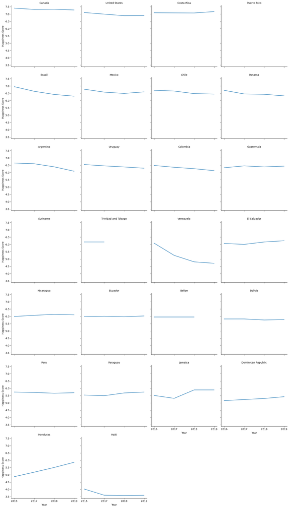

```python
happiness_ind_score = sns.FacetGrid(df, col='Country', col_wrap=4, height=4)
happiness_ind_score.map(sns.lineplot, 'Year', 'Happiness Score')
happiness_ind_score.set_titles('{col_name}')
happiness_ind_score.set_axis_labels('Year', 'Happiness Score')
plt.show()
```

### Finding Factors for Countries Without Stable Happiness Scores

After fiding what countries were the most ustable happiness scores, I wanted to see what the factors were for that change and if there was a common denominator of the change as well. Thus, we can see that:

- Haiti: has the most change in health and social support
- Honduras: has the most change in social support, health, and freedom
- Jamaica: has the most change in social support and generosity
- Venezuela: has the most change in economy, health, and social support

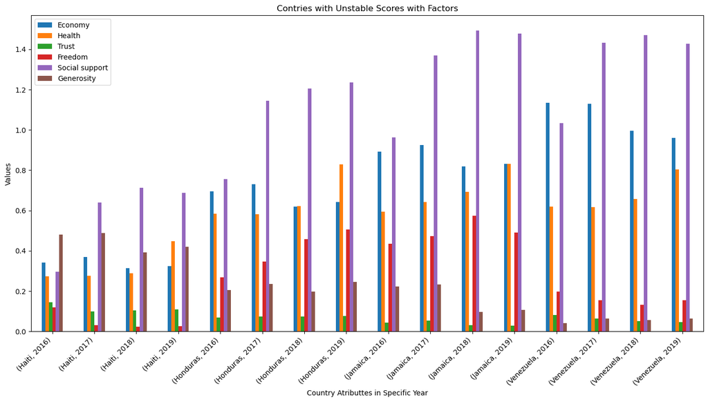

```python
countries_of_interest = ['Venezuela', 'Haiti', 'Jamaica', 'Honduras']

filtered_df = df[df['Country'].isin(countries_of_interest)]

filtered_df.sort_values(by='Country', inplace=True)
filtered_df.set_index(['Country', 'Year'], inplace=True)

fig, ax = plt.subplots(figsize=(14,8))

filtered_df[['Economy', 'Health', 'Trust', 'Freedom', 'Social support', 'Generosity']].plot(kind='bar', ax=ax)

ax.set_title('Contries with Unstable Scores with Factors')

ax.set_xlabel('Country Atributtes in Specific Year')
ax.set_ylabel('Values')

ax.set_xticklabels(ax.get_xticklabels(), rotation=45, ha='right')
plt.tight_layout()
plt.show()
```

### Correlation Factors

I also wanted to check what are the main factors that involve happiness in countries. This is a small dataset so it was easy to see as well with the next data visualization. However, I wanted to add this visual as well to ensure that my speculations were also true.

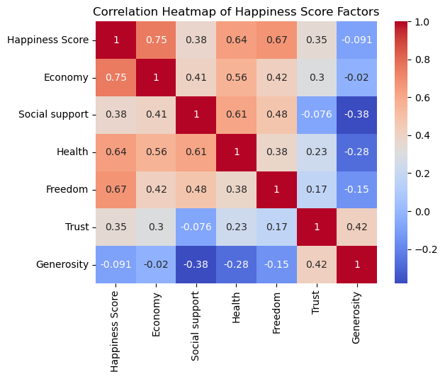

```python
numeric_df = df.select_dtypes(include=[np.number])

correlation_matrix = numeric_df.corr()

sns.heatmap(correlation_matrix, annot=True, cmap='coolwarm')
plt.title('Correlation Heatmap of Happiness Score Factors')
plt.show()
```

### Happiness Score Aspects in Different Years

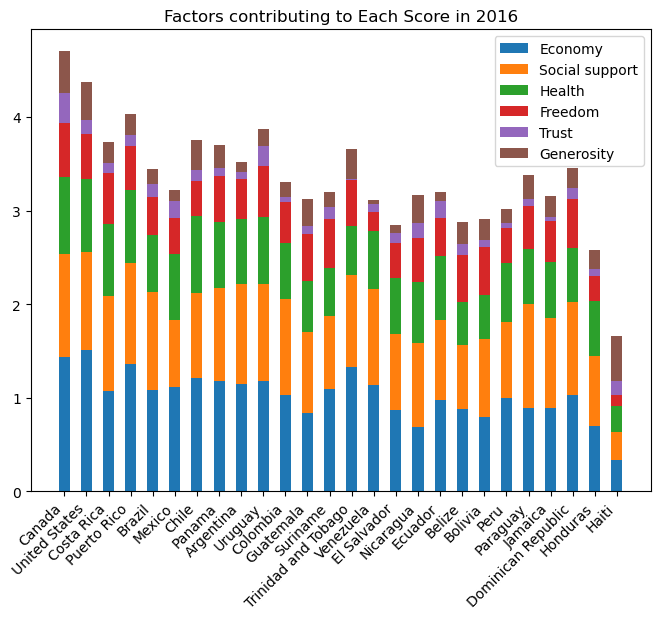

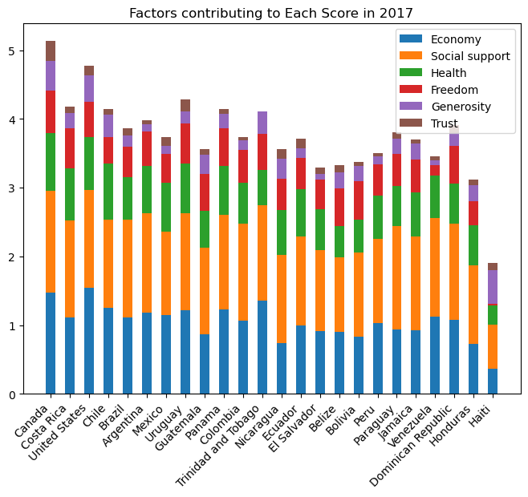

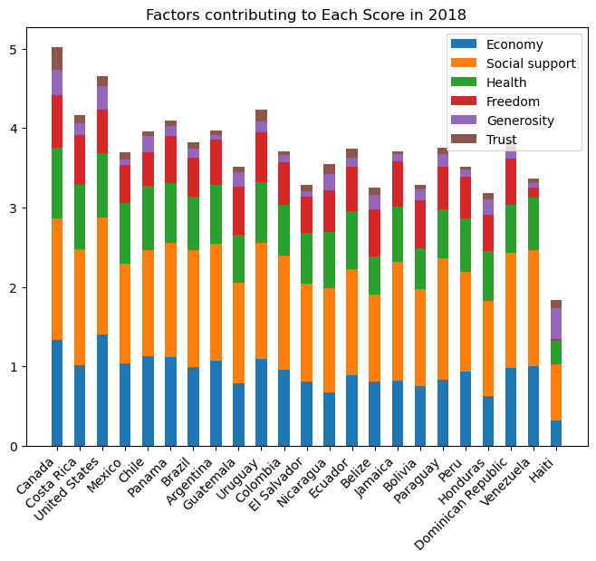

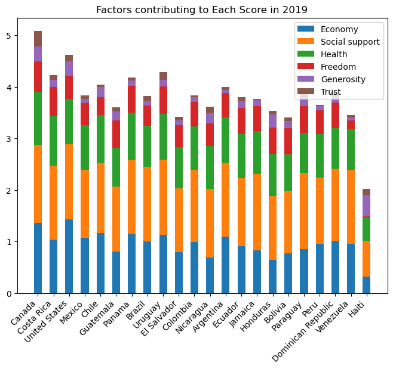

```python
def plot_stacked_bar(df):
    width = 0.5
    bottom = np.zeros(len(df))
    fig, ax = plt.subplots(figsize=(8,6))

    for key, value in df.items():
        if (key!='Country')&(key!='Year')&(key!='Happiness Score'):
            p = ax.bar(df['Country'], value, width, label=key, bottom=bottom)
            bottom += value

    ax.set_title('Factors contributing to Each Score in ' + df['Year'].iloc[0])
    ax.legend()
    plt.xticks(rotation=45, ha='right')

plot_stacked_bar(df_2016)
plot_stacked_bar(df_2017)
plot_stacked_bar(df_2018)
plot_stacked_bar(df_2019)

plt.show()
```

## Conclusion

I would like to, once again, repeat that this dataset was a pretty small one. Another thing that I would like to point out is that the description for these datasets was somewhat broad. Thus, I decided to still showcase my work keeping in mind that there are some assumptions that can be made.

One of the assumptions was the Dystopia score, which was an imaginary country and its happiness level. This score was added to the final happiness score of each country plus the leftover of score that could not be justified in any of the categories below, thus, a imaginary number. Therefore, I decided to only use these categories:

- Economy
- Health
- Trust
- Generosity
- Social Support
- Freedom

The countries with a more drastic change throughout the years 2016-2019 are (either up and down):

- Venezuela
- jamaica
- Honduras
- Haiti